# Project: Train a Quadcopter How to Fly

Design an agent to fly a quadcopter, and then train it using a reinforcement learning algorithm of your choice!

Try to apply the techniques you have learnt, but also feel free to come up with innovative ideas and test them.

## Instructions

Take a look at the files in the directory to better understand the structure of the project.

- `task.py`: Define your task (environment) in this file.
- `agents/`: Folder containing reinforcement learning agents.
  - `policy_search.py`: A sample agent has been provided here.
  - `agent.py`: Develop your agent here.
- `physics_sim.py`: This file contains the simulator for the quadcopter. **DO NOT MODIFY THIS FILE**.

For this project, you will define your own task in `task.py`. Although we have provided a example task to get you started, you are encouraged to change it. Later in this notebook, you will learn more about how to amend this file.

You will also design a reinforcement learning agent in `agent.py` to complete your chosen task.

You are welcome to create any additional files to help you to organize your code. For instance, you may find it useful to define a `model.py` file defining any needed neural network architectures.

## Controlling the Quadcopter

We provide a sample agent in the code cell below to show you how to use the sim to control the quadcopter. This agent is even simpler than the sample agent that you'll examine (in `agents/policy_search.py`) later in this notebook!

The agent controls the quadcopter by setting the revolutions per second on each of its four rotors. The provided agent in the `Basic_Agent` class below always selects a random action for each of the four rotors. These four speeds are returned by the `act` method as a list of four floating-point numbers.

For this project, the agent that you will implement in `agents/agent.py` will have a far more intelligent method for selecting actions!

```python
import random

class Basic_Agent():
    def __init__(self, task):
        self.task = task

    def act(self):
        new_thrust = random.gauss(450., 25.)
        return [new_thrust + random.gauss(0., 1.) for x in range(4)]
```

Run the code cell below to have the agent select actions to control the quadcopter.

Feel free to change the provided values of `runtime`, `init_pose`, `init_velocities`, and `init_angle_velocities` below to change the starting conditions of the quadcopter.

The `labels` list below annotates statistics that are saved while running the simulation. All of this information is saved in a text file `data.txt` and stored in the dictionary `results`.

```python
%load_ext autoreload
%autoreload 2

import csv
import numpy as np
from task_Original import Task

# Modify the values below to give the quadcopter a different starting position.
runtime = 5.                                     # time limit of the episode
init_pose = np.array([0., 0., 10., 0., 0., 0.])  # initial pose
init_velocities = np.array([0., 0., 0.])         # initial velocities
init_angle_velocities = np.array([0., 0., 0.])   # initial angle velocities
file_output = 'data.txt'                         # file name for saved results

# Setup
task = Task(init_pose, init_velocities, init_angle_velocities, runtime)
agent = Basic_Agent(task)
done = False
labels = ['time', 'x', 'y', 'z', 'phi', 'theta', 'psi', 'x_velocity',
          'y_velocity', 'z_velocity', 'phi_velocity', 'theta_velocity',
          'psi_velocity', 'rotor_speed1', 'rotor_speed2', 'rotor_speed3', 'rotor_speed4']
results = {x : [] for x in labels}

# Run the simulation, and save the results.
with open(file_output, 'w') as csvfile:
    writer = csv.writer(csvfile)
    writer.writerow(labels)
    while True:
        rotor_speeds = agent.act()
        _, _, done = task.step(rotor_speeds)
        to_write = [task.sim.time] + list(task.sim.pose) + list(task.sim.v) + list(task.sim.angular_v) + list(rotor_speeds)
        for ii in range(len(labels)):
            results[labels[ii]].append(to_write[ii])
        writer.writerow(to_write)
        if done:
            break
```

Run the code cell below to visualize how the position of the quadcopter evolved during the simulation.

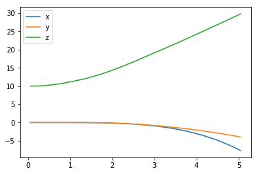

```python
import matplotlib.pyplot as plt
%matplotlib inline

plt.plot(results['time'], results['x'], label='x')
plt.plot(results['time'], results['y'], label='y')
plt.plot(results['time'], results['z'], label='z')
plt.legend()
_ = plt.ylim()
```

The next code cell visualizes the velocity of the quadcopter.

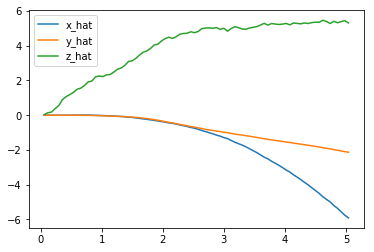

```python
plt.plot(results['time'], results['x_velocity'], label='x_hat')
plt.plot(results['time'], results['y_velocity'], label='y_hat')
plt.plot(results['time'], results['z_velocity'], label='z_hat')
plt.legend()
_ = plt.ylim()
```

Next, you can plot the Euler angles (the rotation of the quadcopter over the $x$-, $y$-, and $z$-axes),

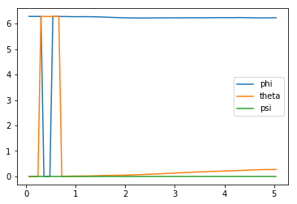

```python
plt.plot(results['time'], results['phi'], label='phi')
plt.plot(results['time'], results['theta'], label='theta')
plt.plot(results['time'], results['psi'], label='psi')
plt.legend()
_ = plt.ylim()
```

before plotting the velocities (in radians per second) corresponding to each of the Euler angles.

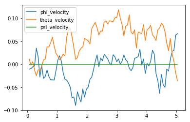

```python
plt.plot(results['time'], results['phi_velocity'], label='phi_velocity')
plt.plot(results['time'], results['theta_velocity'], label='theta_velocity')
plt.plot(results['time'], results['psi_velocity'], label='psi_velocity')
plt.legend()
_ = plt.ylim()
```

Finally, you can use the code cell below to print the agent's choice of actions.

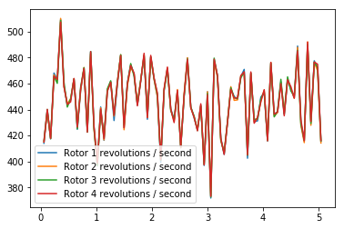

```python
plt.plot(results['time'], results['rotor_speed1'], label='Rotor 1 revolutions / second')
plt.plot(results['time'], results['rotor_speed2'], label='Rotor 2 revolutions / second')
plt.plot(results['time'], results['rotor_speed3'], label='Rotor 3 revolutions / second')
plt.plot(results['time'], results['rotor_speed4'], label='Rotor 4 revolutions / second')
plt.legend()
_ = plt.ylim()
```

When specifying a task, you will derive the environment state from the simulator. Run the code cell below to print the values of the following variables at the end of the simulation:

- `task.sim.pose` (the position of the quadcopter in ($x,y,z$) dimensions and the Euler angles),
- `task.sim.v` (the velocity of the quadcopter in ($x,y,z$) dimensions), and
- `task.sim.angular_v` (radians/second for each of the three Euler angles).

```python
# the pose, velocity, and angular velocity of the quadcopter at the end of the episode
print(task.sim.pose)
print(task.sim.v)
print(task.sim.angular_v)
```

```
[ -7.6678425   -3.96794016  29.77585422   6.23270217   0.26940927   0.        ]
[-5.91770228 -2.13063787  5.31330365]
[ 0.06681916 -0.03613924  0.        ]
```

In the sample task in `task.py`, we use the 6-dimensional pose of the quadcopter to construct the state of the environment at each timestep. However, when amending the task for your purposes, you are welcome to expand the size of the state vector by including the velocity information. You can use any combination of the pose, velocity, and angular velocity - feel free to tinker here, and construct the state to suit your task.

## The Task

A sample task has been provided for you in `task.py`. Open this file in a new window now.

The `__init__()` method is used to initialize several variables that are needed to specify the task.

- The simulator is initialized as an instance of the `PhysicsSim` class (from `physics_sim.py`).
- Inspired by the methodology in the original DDPG paper, we make use of action repeats. For each timestep of the agent, we step the simulation `action_repeats` timesteps. If you are not familiar with action repeats, please read the **Results** section in [the DDPG paper](https://arxiv.org/abs/1509.02971).
- We set the number of elements in the state vector. For the sample task, we only work with the 6-dimensional pose information. To set the size of the state (`state_size`), we must take action repeats into account.
- The environment will always have a 4-dimensional action space, with one entry for each rotor (`action_size=4`). You can set the minimum (`action_low`) and maximum (`action_high`) values of each entry here.
- The sample task in this provided file is for the agent to reach a target position. We specify that target position as a variable.

The `reset()` method resets the simulator. The agent should call this method every time the episode ends. You can see an example of this in the code cell below.

The `step()` method is perhaps the most important. It accepts the agent's choice of action `rotor_speeds`, which is used to prepare the next state to pass on to the agent. Then, the reward is computed from `get_reward()`. The episode is considered done if the time limit has been exceeded, or the quadcopter has travelled outside of the bounds of the simulation.

In the next section, you will learn how to test the performance of an agent on this task.

## The Agent

The sample agent given in `agents/policy_search.py` uses a very simplistic linear policy to directly compute the action vector as a dot product of the state vector and a matrix of weights. Then, it randomly perturbs the parameters by adding some Gaussian noise, to produce a different policy. Based on the average reward obtained in each episode (`score`), it keeps track of the best set of parameters found so far, how the score is changing, and accordingly tweaks a scaling factor to widen or tighten the noise.

Run the code cell below to see how the agent performs on the sample task.

```python
import sys
import pandas as pd
from agents.policy_search import PolicySearch_Agent
from task_Original import Task

num_episodes = 1000
target_pos = np.array([0., 0., 10.])
task = Task(target_pos=target_pos)
agent = PolicySearch_Agent(task)

for i_episode in range(1, num_episodes+1):
    state = agent.reset_episode() # start a new episode
    while True:
        action = agent.act(state)
        next_state, reward, done = task.step(action)
        agent.step(reward, done)
        state = next_state
        if done:
            print("\rEpisode = {:4d}, score = {:7.3f} (best = {:7.3f}), noise_scale = {}".format(
                i_episode, agent.score, agent.best_score, agent.noise_scale), end="")  # [debug]
            break
    sys.stdout.flush()
```

```
Episode =  556, score =  -3.494 (best =   0.187), noise_scale = 3.255
```

```
Episode = 1000, score =  -4.411 (best =   0.187), noise_scale = 3.2
```

This agent should perform very poorly on this task. And that's where you come in!

## Define the Task, Design the Agent, and Train Your Agent!

Amend `task.py` to specify a task of your choosing. If you're unsure what kind of task to specify, you may like to teach your quadcopter to takeoff, hover in place, land softly, or reach a target pose.

After specifying your task, use the sample agent in `agents/policy_search.py` as a template to define your own agent in `agents/agent.py`. You can borrow whatever you need from the sample agent, including ideas on how you might modularize your code (using helper methods like `act()`, `learn()`, `reset_episode()`, etc.).

Note that it is **highly unlikely** that the first agent and task that you specify will learn well. You will likely have to tweak various hyperparameters and the reward function for your task until you arrive at reasonably good behavior.

As you develop your agent, it's important to keep an eye on how it's performing. Use the code above as inspiration to build in a mechanism to log/save the total rewards obtained in each episode to file. If the episode rewards are gradually increasing, this is an indication that your agent is learning.

### Define how to train with train.py with many episodes in one iteration

```python
def train_task(num_episodes, init_pose, init_velocities, init_angle_velocities, runtime, target_pos, action_repeat,
               reward_gains, Parameters, Last10Scores=[0], acc_score_in_iteration=0):

    print('Parameters: ', Parameters)

    task = Task(action_repeat, init_pose, init_velocities, init_angle_velocities, runtime, target_pos,
                reward_gains)
    agent = DDPG(task, Parameters) #PolicySearch_Agent(task)

    # initialize performance monitor
    scores = deque(maxlen=num_episodes)

    # To monitor scores
    acc_score_in_episode=0
    best_score=-100000
    best_episode=0

    for i_episode in range(1, num_episodes+1):
        state = agent.reset_episode() # start a new episode
        state = state + np.concatenate([[randint(-0,0),randint(-0,0),0,0,0,0,0,0,0]] * action_repeat)

        # initialize the sampled reward
        acc_score_in_episode = 0

        while True:
            action = agent.act(state)
            next_state, reward, done = task.step(action)
            agent.step(action, reward, next_state, done) #(reward, done)

            # update the sampled reward, both for this episode and for the entire training
            acc_score_in_episode += reward
            acc_score_in_iteration += reward

            #print('\nLast10Scores before :', Last10Scores)
            #print('\nacc_score_in_episode = ', acc_score_in_episode)
            Last10Scores = np.append(Last10Scores, acc_score_in_episode)
            Last10Scores = np.delete(Last10Scores, [0])
            #print('\nLast10Scores after :', Last10Scores)

            state = next_state
            if done:
                if acc_score_in_episode > best_score:
                    best_score = acc_score_in_episode
                    best_episode = i_episode

                print("\rEpisode = {:4d}, score = {:7.3f} (best = {:7.3f} in episode {}): ".format(
                     i_episode, acc_score_in_episode, best_score, best_episode), end="")  # [debug]
                break
        sys.stdout.flush()
        scores.append(acc_score_in_episode)


    return scores, acc_score_in_iteration, Last10Scores, agent
```

### Define how to plot performance

```python
def plotPerformance(num_episodes, scores):
    plt.plot(np.linspace(0,num_episodes,len(scores),endpoint=False),np.asarray(scores))
    plt.xlabel('Episode Number')
    plt.ylabel('Total Reward pr episode)')
    plt.show()
    # print best episode performance
    print(('Best reward: '), np.max(scores))
```

### Run simulation, after training is done

```python
def run_simulation(LiftOffs):
    # Setup
    #task = Task(init_pose, init_velocities, init_angle_velocities, runtime)
    #agent = Basic_Agent(task)
    done = False
    labels = ['time', 'x', 'y', 'z', 'phi', 'theta', 'psi', 'x_velocity',
              'y_velocity', 'z_velocity', 'phi_velocity', 'theta_velocity',
              'psi_velocity', 'rotor_speed1', 'rotor_speed2', 'rotor_speed3', 'rotor_speed4']
    results = {x : [] for x in labels}

    # Run the simulation, and save the results.
    with open(file_output, 'w') as csvfile:
        writer = csv.writer(csvfile)
        writer.writerow(labels)

        #LiftOffs = 15
        for i in range(0,LiftOffs):
            # Plant liftoffs along a spiral just above the ground
            task = Task(action_repeat, init_pose = np.array([10*i/LiftOffs*np.sin(i/LiftOffs*2*np.pi+2.8),
                                              10*i/LiftOffs*np.cos(i/LiftOffs*2*np.pi+2.8),
                                              2,
                                              0,0.1,0]))
            state = agent.reset_episode() # start a new episode
            #print(state)
            while True:
                rotor_speeds = agent.act(state)
                next_state, _, done = task.step(rotor_speeds)

                to_write = [task.sim.time] + list(task.sim.pose) + list(task.sim.v) \
                            + list(task.sim.angular_v) + list(rotor_speeds)

                for ii in range(len(labels)):
                    results[labels[ii]].append(to_write[ii])
                writer.writerow(to_write)

                state = next_state

                if done:
                    break

    # the pose, velocity, and angular velocity of the quadcopter at the end of the episode
    print(task.sim.pose)
    print(task.sim.v)
    print(task.sim.angular_v)

    import matplotlib.pyplot as plt
    %matplotlib inline

    plt.plot(results['time'], results['x'], label='x')
    plt.plot(results['time'], results['y'], label='y')
    plt.plot(results['time'], results['z'], label='z')
    plt.legend()
    _ = plt.ylim()

    return results
```

### Modify common parameters

```python
import numpy as np

# Modify the values below to give the quadcopter a different starting position.
runtime = 5.                                     # time limit of the episode
init_pose = np.array([0., 0., 5., 0., 0., 0.])  # initial pose: Position and the Euler angles
init_velocities = np.array([0., 0., 0.])         # initial velocities
init_angle_velocities = np.array([0., 0., 0.])   # initial angle velocities
file_output = 'data.txt'                         # file name for saved results
target_pos = np.array([-100., 20., 50., 0.,0.,0., 0.,0.,0.])

#target_pos = np.concatenate([target_pos]*action_repeat)

# Modify rewarding weights:
proximity_gain = 1
proximity_e_gain = 1
position2D_gain = 0
velocity_close_gain = 0
Euler_close_gain = 0
boundary_gain = 0
reward_gains = np.array([proximity_gain, proximity_e_gain, position2D_gain, velocity_close_gain,
                         Euler_close_gain, boundary_gain])

# GRID SEARCH feature
# Set exploration parameters
exploration_mu = [0.0001] # 0.001 # Noise process.
exploration_theta = [0.15, 0.2] # #0.15 # Noise process
exploration_sigma = [0.2, 0.3] #0.2 # Noise process
buffer_size = [300000] #100000. # Replay memory
batch_size = [64] # Replay memory
gamma = [0.5]# #0.99  # discount factor # Algorithm parameters
tau = [0.5, 0.01] # 0.01  # for soft update of target parameters # Algorithm parameters. Changing this from 0 and 0.01 to 0.1 had a great effect: Faster learning, less local minima
Dropoutfactor = [0.5] #0.3 Neural Networks - Dropout - Fraction of the input units to drop
NnDensity = [3.] #, 2.] # Neural Network density - Multiplies density in each layer of the Actor's and Critic's neural networks

# Set size of training for each iteration.
# I'm thinking that if not an iteration starts to improve after num_episodes_in_iteration, I should investigate another combination of hyperparameters
num_episodes_in_iteration = 50
action_repeat = 3
```

### Start training

```
Running new set of combinations, with 4 iterations:

Running iteration number 1 of total 8  * 4 =  32 runs, each with 50 episodes
Parameters:  (0.0001, 0.15, 0.2, 300000, 64, 0.5, 0.5, 0.5, 3.0)
Episode =   50, score = 303.970 (best = 388.759 in episode 48):
Sum of scores in iteration= 10979.9717373
Sum of 10 last scores in iteration:  2800.70685793
Sum of 10 last scores from all iterations in this combination:  2800.70685793

Running iteration number 2 of total 8  * 4 =  32 runs, each with 50 episodes
Parameters:  (0.0001, 0.15, 0.2, 300000, 64, 0.5, 0.5, 0.5, 3.0)
Episode =   50, score = 450.717 (best = 450.717 in episode 50):
Sum of scores in iteration= 20441.2248002
Sum of 10 last scores in iteration:  4263.95767811
Sum of 10 last scores from all iterations in this combination:  7064.66453603

Running iteration number 3 of total 8  * 4 =  32 runs, each with 50 episodes
Parameters:  (0.0001, 0.15, 0.2, 300000, 64, 0.5, 0.5, 0.5, 3.0)
Episode =   50, score = 106.611 (best = 453.717 in episode 32):
Sum of scores in iteration= 8715.56531958
Sum of 10 last scores in iteration:  826.379002437
Sum of 10 last scores from all iterations in this combination:  7891.04353847

Running iteration number 4 of total 8  * 4 =  32 runs, each with 50 episodes
Parameters:  (0.0001, 0.15, 0.2, 300000, 64, 0.5, 0.5, 0.5, 3.0)
Episode =   50, score = 117.482 (best = 452.171 in episode 16):
Sum of scores in iteration= 6971.83801191
Sum of 10 last scores in iteration:  934.287546087
Sum of 10 last scores from all iterations in this combination:  8825.33108456
New combination proposal!
```

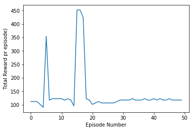

```
Best reward:  452.170731746


Running new set of combinations, with 4 iterations:

Running iteration number 5 of total 8  * 4 =  32 runs, each with 50 episodes
Parameters:  (0.0001, 0.15, 0.2, 300000, 64, 0.5, 0.01, 0.5, 3.0)
Episode =   50, score =  85.269 (best = 449.804 in episode 8):
Sum of scores in iteration= 6587.27405604
Sum of 10 last scores in iteration:  612.972628921
Sum of 10 last scores from all iterations in this combination:  612.972628921

Running iteration number 6 of total 8  * 4 =  32 runs, each with 50 episodes
Parameters:  (0.0001, 0.15, 0.2, 300000, 64, 0.5, 0.01, 0.5, 3.0)
Episode =   50, score = 122.827 (best = 451.763 in episode 21):
Sum of scores in iteration= 7209.22705152
Sum of 10 last scores in iteration:  987.735145136
Sum of 10 last scores from all iterations in this combination:  1600.70777406

Running iteration number 7 of total 8  * 4 =  32 runs, each with 50 episodes
Parameters:  (0.0001, 0.15, 0.2, 300000, 64, 0.5, 0.01, 0.5, 3.0)
Episode =   50, score = 101.214 (best = 453.424 in episode 22):
Sum of scores in iteration= 9739.23175124
Sum of 10 last scores in iteration:  772.638893611
Sum of 10 last scores from all iterations in this combination:  2373.34666767

Running iteration number 8 of total 8  * 4 =  32 runs, each with 50 episodes
Parameters:  (0.0001, 0.15, 0.2, 300000, 64, 0.5, 0.01, 0.5, 3.0)
Episode =   50, score = 292.316 (best = 444.718 in episode 49):
Sum of scores in iteration= 9670.55956501
Sum of 10 last scores in iteration:  2685.6872228
Sum of 10 last scores from all iterations in this combination:  5059.03389046


Running new set of combinations, with 4 iterations:

Running iteration number 9 of total 8  * 4 =  32 runs, each with 50 episodes
Parameters:  (0.0001, 0.15, 0.3, 300000, 64, 0.5, 0.5, 0.5, 3.0)
Episode =   50, score = 449.307 (best = 451.481 in episode 37):
Sum of scores in iteration= 15656.3832347
```

[output cut: 40 more lines]

```

Running iteration number 15 of total 8  * 4 =  32 runs, each with 50 episodes
Parameters:  (0.0001, 0.15, 0.3, 300000, 64, 0.5, 0.01, 0.5, 3.0)
Episode =   50, score = 458.408 (best = 458.408 in episode 50):
Sum of scores in iteration= 10229.9683683
Sum of 10 last scores in iteration:  4331.18486434
Sum of 10 last scores from all iterations in this combination:  9318.97564957

Running iteration number 16 of total 8  * 4 =  32 runs, each with 50 episodes
Parameters:  (0.0001, 0.15, 0.3, 300000, 64, 0.5, 0.01, 0.5, 3.0)
Episode =   50, score = 101.278 (best = 452.706 in episode 41):
Sum of scores in iteration= 14234.739172
Sum of 10 last scores in iteration:  773.101095967
Sum of 10 last scores from all iterations in this combination:  10092.0767455
New combination proposal!
```

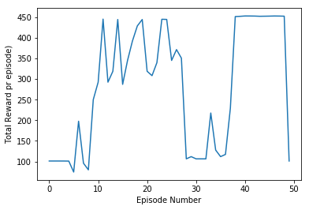

```
Best reward:  452.706355496


Running new set of combinations, with 4 iterations:

Running iteration number 17 of total 8  * 4 =  32 runs, each with 50 episodes
Parameters:  (0.0001, 0.2, 0.2, 300000, 64, 0.5, 0.5, 0.5, 3.0)
Episode =   50, score = 452.236 (best = 452.597 in episode 31):
Sum of scores in iteration= 14327.2115468
Sum of 10 last scores in iteration:  4277.50882405
Sum of 10 last scores from all iterations in this combination:  4277.50882405

Running iteration number 18 of total 8  * 4 =  32 runs, each with 50 episodes
Parameters:  (0.0001, 0.2, 0.2, 300000, 64, 0.5, 0.5, 0.5, 3.0)
Episode =   50, score = 449.665 (best = 452.037 in episode 49):
Sum of scores in iteration= 7732.87137932
Sum of 10 last scores in iteration:  4258.21172653
Sum of 10 last scores from all iterations in this combination:  8535.72055058

Running iteration number 19 of total 8  * 4 =  32 runs, each with 50 episodes
Parameters:  (0.0001, 0.2, 0.2, 300000, 64, 0.5, 0.5, 0.5, 3.0)
Episode =   50, score = 117.220 (best = 450.064 in episode 38):
Sum of scores in iteration= 6191.81494592
Sum of 10 last scores in iteration:  932.720002777
Sum of 10 last scores from all iterations in this combination:  9468.44055336

Running iteration number 20 of total 8  * 4 =  32 runs, each with 50 episodes
Parameters:  (0.0001, 0.2, 0.2, 300000, 64, 0.5, 0.5, 0.5, 3.0)
Episode =   50, score = 271.187 (best = 444.637 in episode 49):
Sum of scores in iteration= 7572.61774436
Sum of 10 last scores in iteration:  2473.99485138
Sum of 10 last scores from all iterations in this combination:  11942.4354047
New combination proposal!
```

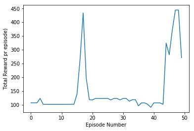

```
Best reward:  444.636714594


Running new set of combinations, with 4 iterations:

Running iteration number 21 of total 8  * 4 =  32 runs, each with 50 episodes
Parameters:  (0.0001, 0.2, 0.2, 300000, 64, 0.5, 0.01, 0.5, 3.0)
Episode =   50, score = 122.573 (best = 456.419 in episode 9):
Sum of scores in iteration= 8148.02065011
Sum of 10 last scores in iteration:  986.188013082
Sum of 10 last scores from all iterations in this combination:  986.188013082

Running iteration number 22 of total 8  * 4 =  32 runs, each with 50 episodes
Parameters:  (0.0001, 0.2, 0.2, 300000, 64, 0.5, 0.01, 0.5, 3.0)
Episode =   50, score = 117.266 (best = 452.593 in episode 10):
Sum of scores in iteration= 6438.950725
Sum of 10 last scores in iteration:  932.969903059
Sum of 10 last scores from all iterations in this combination:  1919.15791614

Running iteration number 23 of total 8  * 4 =  32 runs, each with 50 episodes
Parameters:  (0.0001, 0.2, 0.2, 300000, 64, 0.5, 0.01, 0.5, 3.0)
Episode =   50, score = 117.482 (best = 450.642 in episode 10):
Sum of scores in iteration= 6443.52637577
Sum of 10 last scores in iteration:  934.290580219
Sum of 10 last scores from all iterations in this combination:  2853.44849636

Running iteration number 24 of total 8  * 4 =  32 runs, each with 50 episodes
Parameters:  (0.0001, 0.2, 0.2, 300000, 64, 0.5, 0.01, 0.5, 3.0)
Episode =   50, score = 106.620 (best = 418.203 in episode 43):
Sum of scores in iteration= 7037.77462105
Sum of 10 last scores in iteration:  826.427956632
Sum of 10 last scores from all iterations in this combination:  3679.87645299


Running new set of combinations, with 4 iterations:

Running iteration number 25 of total 8  * 4 =  32 runs, each with 50 episodes
Parameters:  (0.0001, 0.2, 0.3, 300000, 64, 0.5, 0.5, 0.5, 3.0)
Episode =   50, score = 122.596 (best = 128.845 in episode 6):
Sum of scores in iteration= 6116.60794214
```

[output cut: 51 more lines]

```
Sum of scores in iteration= 14931.9333693
Sum of 10 last scores in iteration:  4251.04202366
Sum of 10 last scores from all iterations in this combination:  7475.23396427


4
{'Parameters': (0.0001, 0.2, 0.2, 300000, 64, 0.5, 0.5, 0.5, 3.0), 'agent': <agents.agent.DDPG object at 0x7f40a435b198>, 'Score in iteration': 7572.6177443592951, 'iteration': 20}


Best model found:
Parameters:  (0.0001, 0.2, 0.2, 300000, 64, 0.5, 0.5, 0.5, 3.0)
So here we go :-)

Parameters:  (0.0001, 0.2, 0.2, 300000, 64, 0.5, 0.5, 0.5, 3.0)
Episode =  100, score = 446.578 (best = 457.014 in episode 65):
```

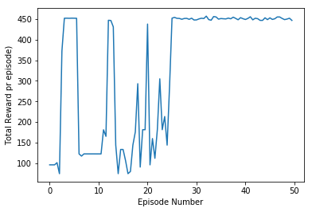

```
Best reward:  457.013864933
The autoreload extension is already loaded. To reload it, use:
  %reload_ext autoreload
[ 13.0273969   -6.7620824   74.17669355   6.28311621   5.68618763   0.        ]
[  8.52326889e+00  -5.08705332e-04   1.55379506e+01]
[ -2.52854026e-05  -3.06356355e-01   0.00000000e+00]
```

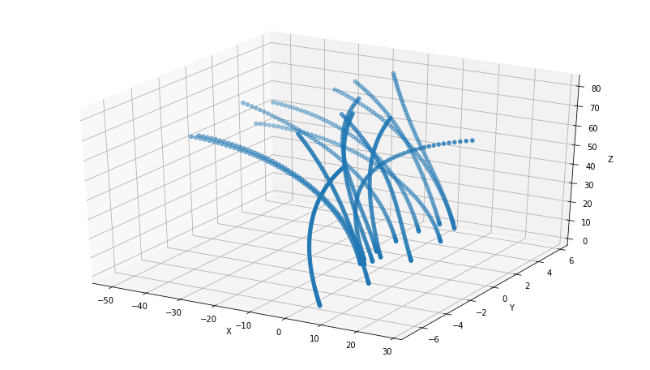

```python
%load_ext autoreload
%autoreload 2

import matplotlib.pyplot as plt
%matplotlib inline

import numpy as np
import sys
import pandas as pd
from agents.agent import ReplayBuffer, OUNoise, Actor, Critic, DDPG
from task import Task
from collections import deque
from random import randint
import itertools
#from pprint import pprint

ExplorationParams = np.array([exploration_mu, exploration_theta, exploration_sigma, buffer_size, batch_size,
                              gamma, tau, Dropoutfactor, NnDensity])

# Combination of parameters:
ExplorationCombs = list(itertools.product(*ExplorationParams))
CombinationsCount=len(ExplorationCombs)




# Run all combinations, and record the best performing model and parameters
BestCombinationScore = -np.inf
iteration=0
combination=0


for Parameters in ExplorationCombs:

    combination+=1
    combination_score = 0

    # Compensate for browser timeout: Run training only on iterations with a higher number than at last timeout
    if combination > 0: # Keep on from iteration 0
        print('Running new set of combinations, with 4 iterations:')

        for comb_set in range(0, 4):
            iteration+=1

            #Prepare measurement of this iteration's quality:
            acc_score_in_iteration = 0
            Last10Scores = [0,0,0,0,0,0,0,0,0,0]

            print('\nRunning iteration number', iteration, 'of total', CombinationsCount, ' * 4 = ',
                  CombinationsCount * 4, 'runs, each with', num_episodes_in_iteration, 'episodes')

            scores, acc_score_in_iteration, Last10Scores, agent = train_task(num_episodes_in_iteration,
                                                                             init_pose, init_velocities,
                                                                             init_angle_velocities,
                                                                             runtime, target_pos, action_repeat,
                                                                             reward_gains,
                                                                             Parameters, Last10Scores,
                                                                             acc_score_in_iteration)
            print('\nSum of scores in iteration=', acc_score_in_iteration)
            #print('10 last scores in iteration: ', Last10Scores)
            print('Sum of 10 last scores in iteration: ', np.sum(Last10Scores))

            combination_score += np.sum(Last10Scores)

            print('Sum of 10 last scores from all iterations in this combination: ', combination_score)

        # Decide if this combination provided a better combination of hyperparameters
        # In this algorithm I have chosen to measure each iteration's quality by the sum of the last 10 scores
        if combination_score > BestCombinationScore:
            print('New combination proposal!')
            BestCombinationScore = combination_score
            BestModel = {'Parameters':Parameters, 'agent':agent,
                         'Score in iteration':acc_score_in_iteration,
                         'iteration':iteration}
            plotPerformance(num_episodes_in_iteration, scores)
        print('\n')

    # Simulate increment in iteration-number:
    else:
        for comb_set in range(0, 4):
            iteration+=1

print(len(BestModel))
print((BestModel))
Parameters=BestModel.get('Parameters')

# Set size of training
print('\n\nBest model found:')
print('Parameters: ', Parameters, '\nSo here we go :-) \n')

# For final training
num_episodes_training = 100 #1000

scores, _ , _ , agent = train_task(num_episodes_training, init_pose, init_velocities, init_angle_velocities, runtime, target_pos,
                                   action_repeat, reward_gains, Parameters,
                                   Last10Scores, acc_score_in_iteration)
plotPerformance(num_episodes_in_iteration, scores)


%load_ext autoreload
%autoreload 2

# Run multiple simulations and plot positions
import csv
results = run_simulation(LiftOffs=15)


# Plot multiple simulations in 3D
from mpl_toolkits.mplot3d import Axes3D
%matplotlib inline

fig = plt.figure(figsize = (14,8))
ax = fig.add_subplot(111, projection='3d')

ax.set_xlabel('X')
ax.set_ylabel('Y')
ax.set_zlabel('Z')

ax.scatter(results['x'], results['y'], results['z'])
```

## Plot the Rewards

Once you are satisfied with your performance, plot the episode rewards, either from a single run, or averaged over multiple runs.

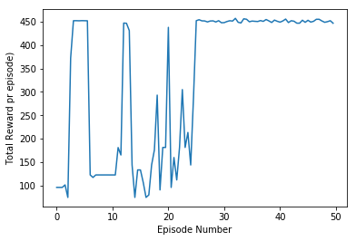

```
Best reward:  457.013864933
(0.0001, 0.2, 0.2, 300000, 64, 0.5, 0.5, 0.5, 3.0)
```

```python
plotPerformance(num_episodes_in_iteration, scores)

print(Parameters)
```

### Simulate several lift-offs in the same space

```
The autoreload extension is already loaded. To reload it, use:
  %reload_ext autoreload
[ -0.75837194  -6.76526705  76.27188732   6.28307102   5.93913319   0.        ]
[  2.56933649e+00  -2.13915931e-03   1.76747710e+01]
[ -3.28704442e-05  -7.38816692e-03   0.00000000e+00]
```

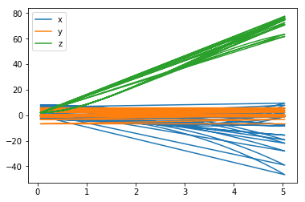

```python
## TODO: Plot the rewards.

%load_ext autoreload
%autoreload 2


import csv

results = run_simulation(LiftOffs=15)
```

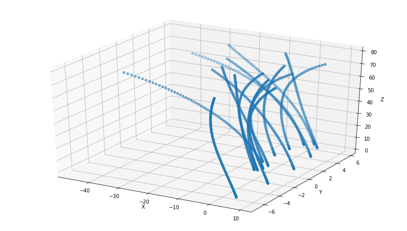

```python
from mpl_toolkits.mplot3d import Axes3D
%matplotlib inline

fig = plt.figure(figsize = (14,8))
ax = fig.add_subplot(111, projection='3d')

ax.set_xlabel('X')
ax.set_ylabel('Y')
ax.set_zlabel('Z')

ax.scatter(results['x'], results['y'], results['z'])
```

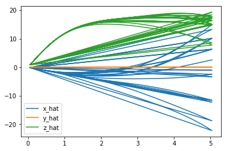

```python
plt.plot(results['time'], results['x_velocity'], label='x_hat')
plt.plot(results['time'], results['y_velocity'], label='y_hat')
plt.plot(results['time'], results['z_velocity'], label='z_hat')
plt.legend()
_ = plt.ylim()
```

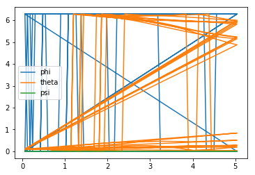

```python
plt.plot(results['time'], results['phi'], label='phi')
plt.plot(results['time'], results['theta'], label='theta')
plt.plot(results['time'], results['psi'], label='psi')
plt.legend()
_ = plt.ylim()
```

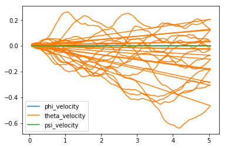

```python
plt.plot(results['time'], results['phi_velocity'], label='phi_velocity')
plt.plot(results['time'], results['theta_velocity'], label='theta_velocity')
plt.plot(results['time'], results['psi_velocity'], label='psi_velocity')
plt.legend()
_ = plt.ylim()
```

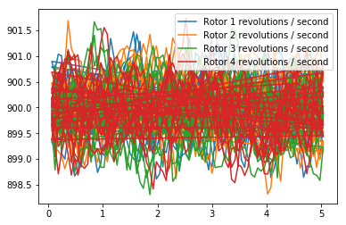

```python
plt.plot(results['time'], results['rotor_speed1'], label='Rotor 1 revolutions / second')
plt.plot(results['time'], results['rotor_speed2'], label='Rotor 2 revolutions / second')
plt.plot(results['time'], results['rotor_speed3'], label='Rotor 3 revolutions / second')
plt.plot(results['time'], results['rotor_speed4'], label='Rotor 4 revolutions / second')
plt.legend()
_ = plt.ylim()
```

## Reflections

**Question 1**: Describe the task that you specified in `task.py`. How did you design the reward function?

**Answer**: In addition to the already provided position and and Euler metrics, I included the velocity and angular velocity metrics: Thus I was able to introduce rewards on every parameter if I saw it fit. Then I prepared a few rewards in the task.py, that could be multiplied with weights/gains provided from the notebook: This was easier than having to change/save/restart the kernel for every new test:

```
    1: reward_proximity:
        My main reward, vith a gradient that grows as the drone closes in to the target
    2: reward_e_proximity (=reward_EXTRA_proximity):
        Extra reward, that reduces as the drone closes in on target.
        Thus, the gradient in the total reward will reduce close to the target (reward-curve becomes less steap),
        forcing the controller to be more fine-tuned while adjusting rotor speed
    3: reward_2D:
        Me thinking that the copter needed extra motivation to move horisontally. Adjusted to zero.
    4: reward_velocity_close:
        A mean to reduce speed when the copter is really close. Adjusted to zero.
    5: reward_Euler_close:
        A mean to reduce rotation when the copter is really close. Adjusted to zero.
```

I seems to me that it is suficcient with my main reward_proximity. Introducing other rewards needs some balancing acts, and I don't have a strategy for this.

**Question 2**: Discuss your agent briefly, using the following questions as a guide:

- What learning algorithm(s) did you try? What worked best for you?
- What was your final choice of hyperparameters (such as $\alpha$, $\gamma$, $\epsilon$, etc.)?
- What neural network architecture did you use (if any)? Specify layers, sizes, activation functions, etc.

**Answer**:

Learning algorithm: I used the provided algorithm from the Udacity lectures: ReplayBuffer, OUNoise, Actor, Critic, DDPG.

I sat Action_repeat to 3. A few tests with a higher number proved not to work well.

Hyperparameters:

[output not shown]

Neural networks:

- I increased the density in the neural networks for the actor and the critic, but kept the number of layers. This density is one of the hyperparameters that can be adjusted: NnDensity.
- I introduced dropout between the laysers to reduce overfitting. The level of dropout is called Dropoutfactor aming the hyperparameters
- I kept the RELU activation function.
- Because of the Action Repeat concept looks along the time-dimension, I think that it is not necessary to introduce a convolutional neural network in the Actor and Critic.

**Question 3**: Using the episode rewards plot, discuss how the agent learned over time.

- Was it an easy task to learn or hard?
- Was there a gradual learning curve, or an aha moment?
- How good was the final performance of the agent? (e.g. mean rewards over the last 10 episodes)

**Answer**:

Easy task: NOT

- This was not an easy task. It took some understanding to put together the code, but the really hard part was the hyperparameters.

Learning kurve: Steep but continously. One insight prepared me for another...

- One thought that arised slowly was: The training model performed different on different target-states, if i did not change the hyperparameters. In other words, the optimum combination of hyperparameters differs for very different target-states.
  - After some consideration, I think this must be natural: If the quadcopter is to travel a great distance to reach its target, this is a very different task than hover in one position.
  - Thus, the model needs to "discover" and fine-tune on different capacities for the quadcopter: It is not optimal to continously rotate and spin in the air if the target is to travel fast.
- One AHA was when i discovered that the penalty for increasing distance from target had to be scaled down a lot, compared to the steady reward that comes with every new step.
- The rewards should not have steep gradients close to the target state, as this wil help to "overshoot" the target. Am i right?
- I see that I did not have time to discower a way to force the copter to haver at one spot when close to the target.

**Question 4**: Briefly summarize your experience working on this project. You can use the following prompts for ideas.

- What was the hardest part of the project? (e.g. getting started, plotting, specifying the task, etc.)
- Did you find anything interesting in how the quadcopter or your agent behaved?

**Answer**:

Hard parts:

- Introduce a way to control all interesting hyperparameters from one place, without having to write directly in the code for agent.py and task.py. This goes especially for the ActionRepeat variable.
- Introduce a concept for grid search, and a way to judge which of the combinations is the best.

Interesting behaviour:

- When simulating, I observed interesing movement when i moved the initial state away from the particular state that I have trained for: Se the 3D plot, the copter may start to slide away in a very different direction after it has passed the target state.
- When training, I tried to have different initilal states, and one target state. This was to prepare the copter for a more real-world situation where more of the 3D space is used. I think the otimum hyperparameters will differ from the ideal situation with only one initial state. But, it took more time to train than I had available.

### For further development: Testing 1-offs, without grid-search as tested hyperparameters may be good enough

Goal: Hovering

- I would be very pleased to see my copter hover in one place after reaching it's target. In those cases where I tested a vertical ascend that should be able to do within the timelimit, the copter just swirled away eventhough I gove heavy rewarding for only be in the vincinity of the target.
  - In order to reach this goal I think I must re-engineer the reward system, maybe unlock some penalties that becomes active only after the copter has reached a desireg target.

Goal: Faster learning with other hyperparameters

- Below I try out (with a few false starts) the set of hyperparameter combination that reached 2nd place in my grid search function. It has EVEN LESS episodes, and the learning curve gets quite rugged. But the trajectories in 3D space shows me that the copter gets the most important instructions in order to ascend in a good direction and after a while most of the trajectories slides out in a less controlled manner... But a cople of them does actually go in the correct direction and almost reaches the target before time runs out.
  - In order to find a stable agent with fast learning, I would incorporate into my grid search the parameters that control gain on different rewards. In that way I will have richer metadata about the learning abilities.

```
The autoreload extension is already loaded. To reload it, use:
  %reload_ext autoreload
Parameters:  [  1.00000000e-04   2.00000000e-01   3.00000000e-01   3.00000000e+05
   6.40000000e+01   5.00000000e-01   5.00000000e-01   5.00000000e-01
   3.00000000e+00]
Episode =   80, score = 448.407 (best = 462.471 in episode 79):
Acc scores in this single iteration:  22631.2576978
Sum of last 10 episodes:  448.40655053
```

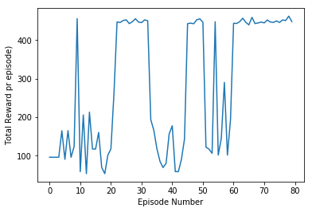

```
Best reward:  462.47146589
[ -12.99358097  -45.85077624  122.93573598    4.89355651    6.04579859
    0.        ]
[ -5.01535247 -26.82950393  18.42609376]
[-0.62488698 -0.12958244  0.        ]
```

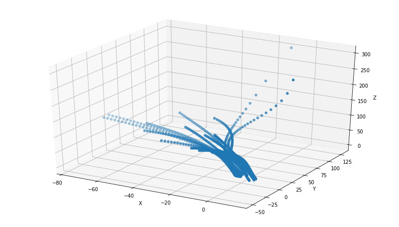

```python
## TODO: Train your agent here.
%load_ext autoreload
%autoreload 2


import matplotlib.pyplot as plt
%matplotlib inline

import numpy as np
import sys
import pandas as pd
from agents.agent import ReplayBuffer, OUNoise, Actor, Critic, DDPG
from task import Task
from collections import deque
from random import randint

# Modify parameters used by the agent
# Best parameters found by my own grid-search:
#Parameters:  (0.0001, 0.2, 0.2, 300000, 64, 0.5, 0.5, 0.5, 3.0)
#Parameters:  (0.0001, 0.2, 0.3, 300000, 64, 0.5, 0.5, 0.5, 3.0)
#Parameters:  (0.0001, 0.15, 0.3, 300000, 64, 0.5, 0.01, 0.5, 3.0)


exploration_mu = 0.0001 #, 0.001 # Noise process.
exploration_theta = 0.2 # #0.15 # Noise process
exploration_sigma = 0.3 #0.2 # Noise process
buffer_size = 300000 #100000. # Replay memory
batch_size = 64 # Replay memory
gamma = 0.5# #0.99  # discount factor
tau = 0.5 #0.01  # for soft update of target parameters # Algorithm parameters. Changing this from 0 and 0.01 to 0.1 had a great effect: Faster learning, less local minima
Dropoutfactor = 0.5 # 0.3 Neural Networks - Dropout - Fraction of the input units to drop
NnDensity = 3 # 1 Neural Network density - Multiplies density in each layer of the Actor's and Critic's neural networks

Parameters = np.array([exploration_mu, exploration_theta, exploration_sigma, buffer_size, batch_size,
                       gamma, tau, Dropoutfactor, NnDensity])


num_episodes_1_iteration = 80 #1000
action_repeat = 3


# Modify the values below to give the quadcopter a different starting position.
runtime = 5.                                     # time limit of the episode
init_pose = np.array([0., 0., 5., 0., 0., 0.])  # initial pose: Position and the Euler angles
init_velocities = np.array([0., 0., 0.])         # initial velocities
init_angle_velocities = np.array([0., 0., 0.])   # initial angle velocities
file_output = 'data.txt'                         # file name for saved results
target_pos = np.array([-100., 20., 50., 0.,0.,0., 0.,0.,0.])

#target_pos = np.concatenate([target_pos]*action_repeat)

proximity_gain = 1
proximity_e_gain = 1
position2D_gain = 0
velocity_close_gain = 0.1
Euler_close_gain = 0
boundary_gain = 0
reward_gains = np.array([proximity_gain, proximity_e_gain, position2D_gain, velocity_close_gain,
                         Euler_close_gain, boundary_gain])

scores, acc_score, Last10Scores, agent = train_task(num_episodes_1_iteration, init_pose, init_velocities,
                                                    init_angle_velocities, runtime, target_pos,
                                                    action_repeat, reward_gains, Parameters)

print('\nAcc scores in this single iteration: ', acc_score)
print('Sum of last 10 episodes: ', np.sum(Last10Scores))

# plot performance
plotPerformance(num_episodes_1_iteration, scores)


# Start simulation with 15 different spots for liftoffs:
import csv
results = run_simulation(LiftOffs=15)



# Plot trajectories in the air:
from mpl_toolkits.mplot3d import Axes3D
%matplotlib inline

fig = plt.figure(figsize = (14,8))
ax = fig.add_subplot(111, projection='3d')

ax.set_xlabel('X')
ax.set_ylabel('Y')
ax.set_zlabel('Z')

ax.scatter(results['x'], results['y'], results['z'])
```